# R Notebook - Meta-analysis by Louise M. Alissa (Selection on male trait)

**ALISSA, L.M. Effect of reproductive site limitation on the intensity of sexual selection and the quality of paternal care: a meta-analysis. 2018. Dissertação (Mestrado) - Instituto de Biociências, Universidade de São Paulo, SP.**

The availability of reproductive sites is a major factor shaping the behavior of males and females in species with resource-based mating systems. Using a meta-analytic approach, we tested five predictions directly or indirectly derived from the mating system theory. We expected that reproductive site limitation would lead to: (1) intense male-male competition for resource possession; (2) high variance in male reproductive success, generating high values of opportunity for sexual selection; (3) high intensity of selection on male traits related to resource possession; (4) high sperm competition risk; and (5) low quality of paternal care. We compiled information from observational and experimental studies that compared the reproductive behavior of individuals of the same species under low and high reproductive site limitation. We found that, when reproductive sites are limited, there is a slight increase in male-male competition, with higher rates of nest takeover and agonistic interactions, and a slight increase in the selection gradient on male traits, with successful males tending to be larger than unsuccessful males. Reproductive site limitation has no consistent effect on the opportunity for sexual selection and on the sperm competition risk. However, territorial males invest more in gonads and lose less paternity when reproductive sites are limited. There is also no clear effect of reproductive site limitation on the quality of paternal care, but few studies have addressed this subject. Taken together, our findings indicate that predictions on how reproductive site limitation affects several aspects of resource-based mating systems have weak empirical support. These predictions do not consider the plasticity in the mating tactics of males and females, which make them too simplistic. Moreover, since the original proposition of the mating system theory, our understanding of sperm competition increased a lot. We now know that accurate predictions on the intensity and direction of sexual selection should take into account both pre- and post-copulatory processes. Finally, the interplay between sexual selection and parental care is complex, and the original framework of mating system theory does not provide sufficient elements to derive clear and taxonomically broad predictions.

Louise Alissa de Morais

e-mail: louisem.alissa@gmail.com

# Organizing

## Loading libraries, setting working directory and loading data set

### Setting the work directory

```r
setwd("C:/Users/louis/Dropbox/Masters_analyses-LMAlissa")
```

### Cleanning possible masking objects

```r
rm(list=ls())
```

### Opening the .csv file

```r
dataset3 <- read.csv(file="basic_dataset3.csv", header=T, dec=".", sep=";")
```

### Looking the data structure

```r
head(dataset3)
```

|  | ES | nID | study | publication_year | species | phylo | class | order | taxon | mating_system | care | exploited_resource | study_type | resource_facet_manipulated | pred | axb | response_variable | r | N |
| --- | --- | --- | --- | --- | --- | --- | --- | --- | --- | --- | --- | --- | --- | --- | --- | --- | --- | --- | --- |
| 1 | E.S. 01 | 5 | Borgia 1982 | 1982 | Scatophaga stercoraria | Scatophaga_stercoraria | Insecta | Diptera | 1_artro | polygamy | no_care | pats of cow | exp_field | quant | mean male size | b | mean size of amplexed males (mm) | 0.477 | 78 |
| 2 | E.S. 02 | 5 | Borgia 1982 | 1982 | Scatophaga stercoraria | Scatophaga_stercoraria | Insecta | Diptera | 1_artro | polygamy | no_care | pats of cow | exp_field | quant | mean male size | b | mean size of amplexed males (mm) | 0.378 | 162 |
| 3 | E.S. 03 | 11 | Debuse et al 2003 | 2003 | Homarus gammarus | Homarus_gammarus | Malacostraca | Decapoda | 1_artro | polygamy | maternal | rock crevices | exp_lab | quant | mean male size | b | nest-owner mean carapace lenght (mm) | 0.156 | 99 |
| 4 | E.S. 04 | 11 | Debuse et al 2003 | 2003 | Homarus gammarus | Homarus_gammarus | Malacostraca | Decapoda | 1_artro | polygamy | maternal | rock crevices | exp_lab | quant | mean male size | a | nest-owner mean claw volume (mm3) | 0.185 | 85 |
| 5 | E.S. 05 | 22 | Kelly 2008 | 2008 | Hemideina crassidens | Hemideina_crassidens | Insecta | Orthoptera | 1_artro | polygamy | maternal | tree hollows or artificial galleries | exp_field | qualit | mean male size | a | mean head length (mm) of successful males | -0.003 | 99 |
| 6 | E.S. 06 | 22 | Kelly 2008 | 2008 | Hemideina crassidens | Hemideina_crassidens | Insecta | Orthoptera | 1_artro | polygamy | maternal | tree hollows or artificial galleries | exp_field | qualit | mean male size | a | mean head length (mm) of successful males | 0.020 | 85 |

```r
tail(dataset3)
```

|  | ES | nID | study | publication_year | species | phylo | class | order | taxon | mating_system | care | exploited_resource | study_type | resource_facet_manipulated | pred | axb | response_variable | r | N |
| --- | --- | --- | --- | --- | --- | --- | --- | --- | --- | --- | --- | --- | --- | --- | --- | --- | --- | --- | --- |
| 64 | E.S. 64 | 13 | Duckworth 2006 | 2006 | Sialia mexicana | Sialia_mexicana | Aves | Passeriformes | 4_aves | monogamy | biparental | tree hollows and nest box | obs | quant | selection gradient | b | standardized selection gradient for fecundity on tail lenght (mm) | 0.468 | 100 |
| 65 | E.S. 65 | 13 | Duckworth 2006 | 2006 | Sialia mexicana | Sialia_mexicana | Aves | Passeriformes | 4_aves | monogamy | biparental | tree hollows and nest box | obs | quant | selection gradient | b | standardized selection gradient for fecundity on tarsus lenght (mm) | 0.395 | 153 |
| 66 | E.S. 66 | 13 | Duckworth 2006 | 2006 | Sialia mexicana | Sialia_mexicana | Aves | Passeriformes | 4_aves | monogamy | biparental | tree hollows and nest box | obs | quant | selection gradient | b | standardized selection gradient for fecundity on wing lenght (mm) | 0.036 | 87 |
| 67 | E.S. 67 | 20 | Jacot et al 2009 | 2009 | Cyanistes caeruleus | Cyanistes_caeruleus | Aves | Passeriformes | 4_aves | polygamy | biparental | tree hollows and nest box | exp_field | quant | mean male size | b | mean body mass of nest owner males (g) | -0.150 | 55 |
| 68 | E.S. 68 | 20 | Jacot et al 2009 | 2009 | Cyanistes caeruleus | Cyanistes_caeruleus | Aves | Passeriformes | 4_aves | polygamy | biparental | tree hollows and nest box | exp_field | quant | mean male size | b | mean tarsus length of nest owner males (mm) | 0.000 | 55 |
| 69 | E.S. 69 | 20 | Jacot et al 2009 | 2009 | Cyanistes caeruleus | Cyanistes_caeruleus | Aves | Passeriformes | 4_aves | polygamy | biparental | tree hollows and nest box | exp_field | quant | mean male size | b | mean wing length of nest owner males (mm) | 0.228 | 55 |

```r
str(dataset3)
```

```
'data.frame':   69 obs. of  19 variables:
 $ ES                        : Factor w/ 69 levels "E.S. 01","E.S. 02",..: 1 2 3 4 5 6 7 8 9 10 ...
 $ nID                       : int  5 5 11 11 22 22 22 22 22 22 ...
 $ study                     : Factor w/ 20 levels "Bessert et al 2007",..: 2 2 4 4 11 11 11 11 11 11 ...
 $ publication_year          : Factor w/ 17 levels "1980","1982",..: 2 2 8 8 12 12 12 12 12 12 ...
 $ species                   : Factor w/ 15 levels "Archocentrus nigrofasciatus",..: 14 14 7 7 6 6 6 6 6 6 ...
 $ phylo                     : Factor w/ 15 levels "Archocentrus_nigrofasciatus",..: 14 14 7 7 6 6 6 6 6 6 ...
 $ class                     : Factor w/ 5 levels "Actinopterygii",..: 4 4 5 5 4 4 4 4 4 4 ...
 $ order                     : Factor w/ 9 levels " Scorpaeniformes",..: 5 5 4 4 7 7 7 7 7 7 ...
 $ taxon                     : Factor w/ 3 levels "1_artro","2_pisc",..: 1 1 1 1 1 1 1 1 1 1 ...
 $ mating_system             : Factor w/ 2 levels "monogamy","polygamy": 2 2 2 2 2 2 2 2 2 2 ...
 $ care                      : Factor w/ 4 levels "biparental","maternal",..: 3 3 2 2 2 2 2 2 2 2 ...
 $ exploited_resource        : Factor w/ 16 levels "bivalve shells",..: 7 7 8 8 14 14 14 14 14 14 ...
 $ study_type                : Factor w/ 3 levels "exp_field","exp_lab",..: 1 1 2 2 1 1 1 1 1 1 ...
 $ resource_facet_manipulated: Factor w/ 4 levels "dispo","l","qualit",..: 4 4 4 4 3 3 3 3 3 3 ...
 $ pred                      : Factor w/ 3 levels "linear selection gradient (beta) ",..: 2 2 2 2 2 2 2 2 2 2 ...
 $ axb                       : Factor w/ 2 levels "a","b": 2 2 2 1 1 1 1 1 1 1 ...
 $ response_variable         : Factor w/ 39 levels "(S nest) gradient of selection in respect to male lenght (cm transformed in mm)",..: 23 23 29 30 14 14 14 14 15 15 ...
 $ r                         : num  0.477 0.378 0.156 0.185 -0.003 0.02 0.011 0.007 0.005 0.028 ...
 $ N                         : int  78 162 99 85 99 85 70 72 99 85 ...
```

### Setting the rigth classes for variables

```r
dataset3$nID <- as.factor(dataset3$nID)
dataset3$publication_year <- as.factor(dataset3$publication_year)
str(dataset3)
```

```
'data.frame':   69 obs. of  19 variables:
 $ ES                        : Factor w/ 69 levels "E.S. 01","E.S. 02",..: 1 2 3 4 5 6 7 8 9 10 ...
 $ nID                       : Factor w/ 20 levels "2","5","10","11",..: 2 2 4 4 9 9 9 9 9 9 ...
 $ study                     : Factor w/ 20 levels "Bessert et al 2007",..: 2 2 4 4 11 11 11 11 11 11 ...
 $ publication_year          : Factor w/ 17 levels "1980","1982",..: 2 2 8 8 12 12 12 12 12 12 ...
 $ species                   : Factor w/ 15 levels "Archocentrus nigrofasciatus",..: 14 14 7 7 6 6 6 6 6 6 ...
 $ phylo                     : Factor w/ 15 levels "Archocentrus_nigrofasciatus",..: 14 14 7 7 6 6 6 6 6 6 ...
 $ class                     : Factor w/ 5 levels "Actinopterygii",..: 4 4 5 5 4 4 4 4 4 4 ...
 $ order                     : Factor w/ 9 levels " Scorpaeniformes",..: 5 5 4 4 7 7 7 7 7 7 ...
 $ taxon                     : Factor w/ 3 levels "1_artro","2_pisc",..: 1 1 1 1 1 1 1 1 1 1 ...
 $ mating_system             : Factor w/ 2 levels "monogamy","polygamy": 2 2 2 2 2 2 2 2 2 2 ...
 $ care                      : Factor w/ 4 levels "biparental","maternal",..: 3 3 2 2 2 2 2 2 2 2 ...
 $ exploited_resource        : Factor w/ 16 levels "bivalve shells",..: 7 7 8 8 14 14 14 14 14 14 ...
 $ study_type                : Factor w/ 3 levels "exp_field","exp_lab",..: 1 1 2 2 1 1 1 1 1 1 ...
 $ resource_facet_manipulated: Factor w/ 4 levels "dispo","l","qualit",..: 4 4 4 4 3 3 3 3 3 3 ...
 $ pred                      : Factor w/ 3 levels "linear selection gradient (beta) ",..: 2 2 2 2 2 2 2 2 2 2 ...
 $ axb                       : Factor w/ 2 levels "a","b": 2 2 2 1 1 1 1 1 1 1 ...
 $ response_variable         : Factor w/ 39 levels "(S nest) gradient of selection in respect to male lenght (cm transformed in mm)",..: 23 23 29 30 14 14 14 14 15 15 ...
 $ r                         : num  0.477 0.378 0.156 0.185 -0.003 0.02 0.011 0.007 0.005 0.028 ...
 $ N                         : int  78 162 99 85 99 85 70 72 99 85 ...
```

## Loanding and dealing with the phylogeny

### First, opening the file .tree (newik). The tree was constructed on Mesquite.

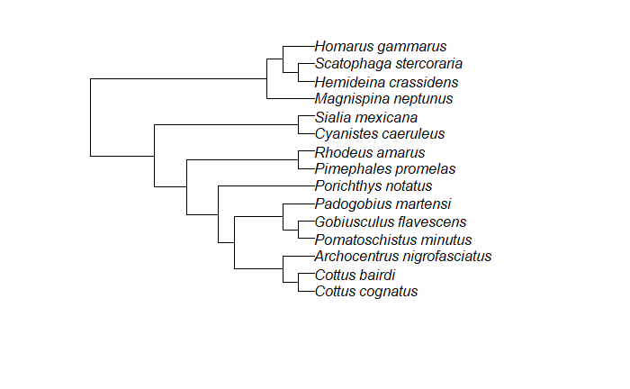

```r
tree3 <- read.tree('mytree3_mod.tre')
plot(tree3)
```

### Calculating the correlation matrix, with weighted values for relatedness

```r
tree3_mod <- compute.brlen(tree3, method="Grafen")
cor <- vcv(tree3_mod, corr =T)
```

### Cheking if every specie in the data is present in the tree

```r
spp <- data.frame(spp = unique(dataset3$phylo))
row.names(spp) <- spp$spp
```

```r
check.phylo <- name.check(tree3_mod, spp)
check.phylo
```

```
[1] "OK"
```

## Transforming r in Fisher’s Z

In our table we have values of r, here we transform to Z

```r
dataset3 <- escalc(measure="ZCOR", ri=r, ni=N, data=dataset3, append=TRUE)
attach(dataset3)
```

# Selecting the random-effects based on AICc

Randon variables: the effect size identity (id.mc), the article identity(nID), species (species) and the phylogenetic effect (phylo). Without moderators here.

### Creating an object for list each effect size

```r
id.mt <- as.factor(1:(length(dataset3$r)))
```

### Constructing models

```r
# id |--> AICc =  81.4810
m_randon1 <- rma.mv(yi=yi, V=vi, random = list(~ 1|id.mt), data=dataset3, method="ML")
summary(m_randon1)
```

```
Multivariate Meta-Analysis Model (k = 69; method: ML)

  logLik  Deviance       AIC       BIC      AICc
-38.6496  242.3281   81.2991   85.7673   81.4810

Variance Components:

            estim    sqrt  nlvls  fixed  factor
sigma^2    0.1623  0.4028     69     no   id.mt

Test for Heterogeneity:
Q(df = 68) = 850.2018, p-val < .0001

Model Results:

estimate      se    zval    pval   ci.lb   ci.ub
  0.1298  0.0510  2.5479  0.0108  0.0300  0.2297  *

---
Signif. codes:  0 *** 0.001 ** 0.01 * 0.05 . 0.1   1
```

```r
# id + phylo |--> AICc = 83.6684
m_randon2 <- rma.mv(yi=yi, V=vi, random = list(~ 1|id.mt, ~1|phylo),R=list(phylo=cor), data=dataset3, method="ML")
summary(m_randon2)
```

```
Multivariate Meta-Analysis Model (k = 69; method: ML)

  logLik  Deviance       AIC       BIC      AICc
-38.6496  242.3281   83.2991   90.0015   83.6684

Variance Components:

            estim    sqrt  nlvls  fixed  factor    R
sigma^2.1  0.1623  0.4028     69     no   id.mt   no
sigma^2.2  0.0000  0.0000     15     no   phylo  yes

Test for Heterogeneity:
Q(df = 68) = 850.2018, p-val < .0001

Model Results:

estimate      se    zval    pval   ci.lb   ci.ub
  0.1298  0.0510  2.5479  0.0108  0.0300  0.2297  *

---
Signif. codes:  0 *** 0.001 ** 0.01 * 0.05 . 0.1   1
```

```r
# id + species |--> AICc = 83.6684
m_randon3 <- rma.mv(yi=yi, V=vi, random = list(~ 1|id.mt, ~1|species), data=dataset3, method="ML")
summary(m_randon3)
```

```
Multivariate Meta-Analysis Model (k = 69; method: ML)

  logLik  Deviance       AIC       BIC      AICc
-38.6496  242.3281   83.2991   90.0015   83.6684

Variance Components:

            estim    sqrt  nlvls  fixed   factor
sigma^2.1  0.1623  0.4028     69     no    id.mt
sigma^2.2  0.0000  0.0000     15     no  species

Test for Heterogeneity:
Q(df = 68) = 850.2018, p-val < .0001

Model Results:

estimate      se    zval    pval   ci.lb   ci.ub
  0.1298  0.0510  2.5479  0.0108  0.0300  0.2297  *

---
Signif. codes:  0 *** 0.001 ** 0.01 * 0.05 . 0.1   1
```

```r
# id + nID |--> AICc = 83.6684
m_randon4 <- rma.mv(yi=yi, V=vi, random = list(~ 1|id.mt, ~1|nID), data=dataset3, method="ML")
summary(m_randon4)
```

```
Multivariate Meta-Analysis Model (k = 69; method: ML)

  logLik  Deviance       AIC       BIC      AICc
-38.6496  242.3281   83.2991   90.0015   83.6684

Variance Components:

            estim    sqrt  nlvls  fixed  factor
sigma^2.1  0.1623  0.4028     69     no   id.mt
sigma^2.2  0.0000  0.0000     20     no     nID

Test for Heterogeneity:
Q(df = 68) = 850.2018, p-val < .0001

Model Results:

estimate      se    zval    pval   ci.lb   ci.ub
  0.1298  0.0510  2.5479  0.0108  0.0300  0.2297  *

---
Signif. codes:  0 *** 0.001 ** 0.01 * 0.05 . 0.1   1
```

```r
# id + specie + phylo |--> AICc = 85.9241
m_randon5 <- rma.mv(yi=yi, V=vi, random = list(~ 1|id.mt, ~1|species, ~1|phylo), R=list(phylo=cor), data=dataset3, method="ML")
summary(m_randon5)
```

```
Multivariate Meta-Analysis Model (k = 69; method: ML)

  logLik  Deviance       AIC       BIC      AICc
-38.6496  242.3281   85.2991   94.2356   85.9241

Variance Components:

            estim    sqrt  nlvls  fixed   factor    R
sigma^2.1  0.1623  0.4028     69     no    id.mt   no
sigma^2.2  0.0000  0.0000     15     no  species   no
sigma^2.3  0.0000  0.0000     15     no    phylo  yes

Test for Heterogeneity:
Q(df = 68) = 850.2018, p-val < .0001

Model Results:

estimate      se    zval    pval   ci.lb   ci.ub
  0.1298  0.0510  2.5479  0.0108  0.0300  0.2297  *

---
Signif. codes:  0 *** 0.001 ** 0.01 * 0.05 . 0.1   1
```

```r
# id + nID + specie |--> AICc =  85.9241
m_randon6 <- rma.mv(yi=yi, V=vi, random = list(~ 1|id.mt, ~1|nID, ~1|species), data=dataset3, method="ML")
summary(m_randon6)
```

```
Multivariate Meta-Analysis Model (k = 69; method: ML)

  logLik  Deviance       AIC       BIC      AICc
-38.6496  242.3281   85.2991   94.2356   85.9241

Variance Components:

            estim    sqrt  nlvls  fixed   factor
sigma^2.1  0.1623  0.4028     69     no    id.mt
sigma^2.2  0.0000  0.0000     20     no      nID
sigma^2.3  0.0000  0.0000     15     no  species

Test for Heterogeneity:
Q(df = 68) = 850.2018, p-val < .0001

Model Results:

estimate      se    zval    pval   ci.lb   ci.ub
  0.1298  0.0510  2.5479  0.0108  0.0300  0.2297  *

---
Signif. codes:  0 *** 0.001 ** 0.01 * 0.05 . 0.1   1
```

```r
# id + nID + phylo |--> AICc = 85.9241
m_randon7 <- rma.mv(yi=yi, V=vi, random = list(~ 1|id.mt, ~1|nID, ~1|phylo),R=list(phylo=cor), data=dataset3, method="ML")
summary(m_randon7)
```

```
Multivariate Meta-Analysis Model (k = 69; method: ML)

  logLik  Deviance       AIC       BIC      AICc
-38.6496  242.3281   85.2991   94.2356   85.9241

Variance Components:

            estim    sqrt  nlvls  fixed  factor    R
sigma^2.1  0.1623  0.4028     69     no   id.mt   no
sigma^2.2  0.0000  0.0000     20     no     nID   no
sigma^2.3  0.0000  0.0000     15     no   phylo  yes

Test for Heterogeneity:
Q(df = 68) = 850.2018, p-val < .0001

Model Results:

estimate      se    zval    pval   ci.lb   ci.ub
  0.1298  0.0510  2.5479  0.0108  0.0300  0.2297  *

---
Signif. codes:  0 *** 0.001 ** 0.01 * 0.05 . 0.1   1
```

```r
# id + nID + specie + phylo |--> AICc = 88.2515
m_randon8 <- rma.mv(yi=yi, V=vi, random = list(~ 1|id.mt, ~1|nID, ~1|species, ~1|phylo), R=list(phylo=cor), data=dataset3, method="ML")
summary(m_randon8)
```

```
Multivariate Meta-Analysis Model (k = 69; method: ML)

  logLik  Deviance       AIC       BIC      AICc
-38.6496  242.3281   87.2991   98.4697   88.2515

Variance Components:

            estim    sqrt  nlvls  fixed   factor    R
sigma^2.1  0.1623  0.4028     69     no    id.mt   no
sigma^2.2  0.0000  0.0000     20     no      nID   no
sigma^2.3  0.0000  0.0000     15     no  species   no
sigma^2.4  0.0000  0.0000     15     no    phylo  yes

Test for Heterogeneity:
Q(df = 68) = 850.2018, p-val < .0001

Model Results:

estimate      se    zval    pval   ci.lb   ci.ub
  0.1298  0.0510  2.5479  0.0108  0.0300  0.2297  *

---
Signif. codes:  0 *** 0.001 ** 0.01 * 0.05 . 0.1   1
```

### Creating a table to compare models, looking to AICc

```r
ICtab(m_randon1, m_randon2, m_randon3, m_randon4, m_randon5, m_randon7, m_randon8, type= "AICc")
```

```
          dAICc df
m_randon1 0.0   2
m_randon3 2.2   3
m_randon4 2.2   3
m_randon2 2.2   3
m_randon5 4.4   4
m_randon7 4.4   4
m_randon8 6.8   5
```

# Performing - data set 3 - SELECTION ON MALE TRAIT

## The meta-analytic model

Randon variables: the effect size identity, the article identity, species and the phylogenetic effect. Without moderators here.

```r
meta.mt.phylo <- rma.mv(yi=yi, V=vi, random = list(~ 1|id.mt, ~1|nID, ~1|species, ~1|phylo), R=list(phylo=cor) , data=dataset3, method="REML")
```

### Looking the results

```r
summary(meta.mt.phylo)
```

```
Multivariate Meta-Analysis Model (k = 69; method: REML)

  logLik  Deviance       AIC       BIC      AICc
-38.5790   77.1579   87.1579   98.2555   88.1257

Variance Components:

            estim    sqrt  nlvls  fixed   factor    R
sigma^2.1  0.1638  0.4047     69     no    id.mt   no
sigma^2.2  0.0000  0.0001     20     no      nID   no
sigma^2.3  0.0013  0.0367     15     no  species   no
sigma^2.4  0.0000  0.0001     15     no    phylo  yes

Test for Heterogeneity:
Q(df = 68) = 850.2018, p-val < .0001

Model Results:

estimate      se    zval    pval   ci.lb   ci.ub
  0.1331  0.0533  2.4989  0.0125  0.0287  0.2375  *

---
Signif. codes:  0 *** 0.001 ** 0.01 * 0.05 . 0.1   1
```

### Overall effect and CI converted back to “r”

```r
predict(meta.mt.phylo, transf=transf.ztor)#  overall effect and CI converted back to "r"
```

```
   pred  ci.lb  ci.ub   cr.lb  cr.ub
 0.1323 0.0287 0.2332 -0.5851 0.7336
```

### Basic forest plot (made with metafor package)

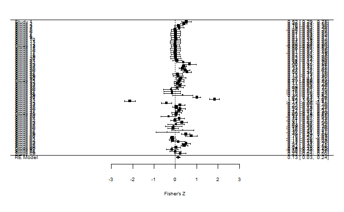

```r
forest(meta.mt.phylo, cex=.6, xlab="Fisher's Z")
```

## Heterogeinity

*Based in Nakagawa & Santos (2012)*

```r
s2m.mt <- sum(1/meta.mt.phylo$vi) * (meta.mt.phylo$k-1) / (sum(1/meta.mt.phylo$vi)^2 - sum((1/meta.mt.phylo$vi)^2))
s2m.mt #s^2_m variation within study
```

```
[1] 0.01229924
```

```r
s2t.mt <- sum(meta.mt.phylo$sigma2) + s2m.mt
s2t.mt #s^2_t variation total
```

```
[1] 0.1774259
```

### The total amount of variance

```r
total_I2.mt <- sum(meta.mt.phylo$sigma2)/s2t.mt
total_I2.mt*100 # the "total" variation
```

```
[1] 93.06796
```

### Proportion of variance from effect size id

```r
id.mt_I2 <- meta.mt.phylo$sigma2[1]/s2t.mt
id.mt_I2*100
```

```
[1] 92.30887
```

### Proportion of variance from study id

```r
nID_I2 <- meta.mt.phylo$sigma2[2]/s2t.mt
nID_I2*100
```

```
[1] 7.353778e-06
```

### Proportion of variance from species id

```r
especies_I2 <- meta.mt.phylo$sigma2[3]/s2t.mt
especies_I2*100
```

```
[1] 0.7590758
```

### Proportion of variance from phylo

```r
phylo_I2 <- meta.mt.phylo$sigma2[4]/s2t.mt
phylo_I2*100
```

```
[1] 4.034528e-06
```

## The phylogenetic effect

Very low, in this case.

```r
H2.mt<-meta.mt.phylo$sigma2[4] / sum(meta.mt.phylo$sigma2)
H2.mt*100
```

```
[1] 4.335034e-06
```

## Qb

Testing if the mean effect is different in different taxa.

```r
mean_taxon <- rma.mv(yi=yi, V=vi, random = list(~ 1|id.mt, ~1|nID, ~1|species, ~1|phylo), R=list(phylo=cor) , data=dataset3, method="REML", mod= ~ taxon-1)
summary(mean_taxon)
```

```
Multivariate Meta-Analysis Model (k = 69; method: REML)

  logLik  Deviance       AIC       BIC      AICc
-38.0294   76.0587   90.0587  105.3863   91.9897

Variance Components:

            estim    sqrt  nlvls  fixed   factor    R
sigma^2.1  0.1653  0.4065     69     no    id.mt   no
sigma^2.2  0.0000  0.0000     20     no      nID   no
sigma^2.3  0.0000  0.0000     15     no  species   no
sigma^2.4  0.0165  0.1283     15     no    phylo  yes

Test for Residual Heterogeneity:
QE(df = 66) = 833.2985, p-val < .0001

Test of Moderators (coefficient(s) 1:3):
QM(df = 3) = 2.5643, p-val = 0.4638

Model Results:

              estimate      se    zval    pval    ci.lb   ci.ub
taxon1_artro    0.0761  0.1549  0.4915  0.6230  -0.2274  0.3797
taxon2_pisc     0.1764  0.1259  1.4019  0.1609  -0.0702  0.4231
taxon4_aves     0.1783  0.2140  0.8333  0.4047  -0.2411  0.5978

---
Signif. codes:  0 *** 0.001 ** 0.01 * 0.05 . 0.1   1
```

# Testing publication bias

## Egger’s regression

### Radial figure

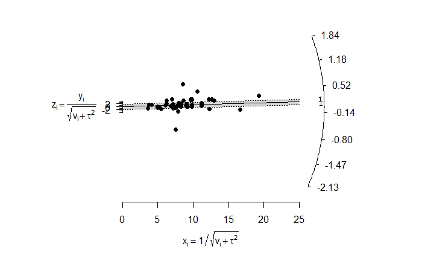

```r
# Egger's figure
radial.rma(meta.mt.phylo)
```

### Egger’s regression test

```r
s.e.mt <- sqrt(dataset3$vi)
precision.mt <- 1/s.e.mt
Egger.mt <- lm(dataset3$yi*precision.mt ~ precision.mt)
summary(Egger.mt)
```

```
Call:
lm(formula = dataset3$yi * precision.mt ~ precision.mt)

Residuals:
     Min       1Q   Median       3Q      Max
-16.9168  -1.1554  -0.6314   1.1131  14.5193

Coefficients:
             Estimate Std. Error t value Pr(>|t|)
(Intercept)   -1.9076     1.4712  -1.297   0.1992
precision.mt   0.3661     0.1626   2.251   0.0277 *
---
Signif. codes:  0 *** 0.001 ** 0.01 * 0.05 . 0.1   1

Residual standard error: 3.518 on 67 degrees of freedom
Multiple R-squared:  0.0703,    Adjusted R-squared:  0.05643
F-statistic: 5.066 on 1 and 67 DF,  p-value: 0.02768
```

## Funnel Plot

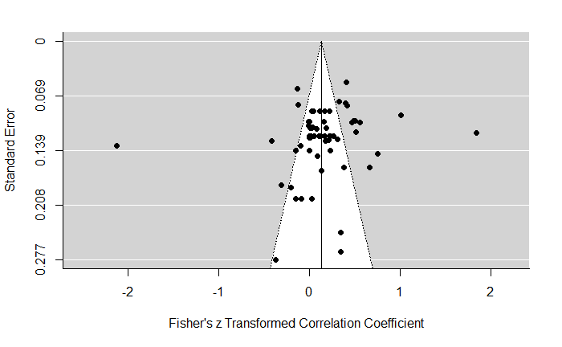

```r
# Basic funnel plot
funnel(meta.mt.phylo)
```

```r
#plot 1 ("plot")
plot(dataset3$yi,
     precision.mt,
     xlab="Fisher's Z",
     ylab="precision (1/s.e.)",
     cex=1.5,
     xlim=c(min(dataset3$yi, na.rm=T)-0.5,max(dataset3$yi, na.rm=T)+0.5),
     ylim=c(0,max(precision.mt, na.rm=T)*1.2))
abline(v=meta.mt.phylo[1], lwd=3)
```

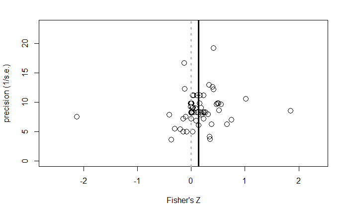

```r
abline(v=0, col=8, lwd=3, lty="dotted")
```

```r
#plot 2 ("ggplot")
dataset3$precision.mt <-precision.mt
funnel_2 <- ggplot(dataset3, aes(x=yi, y=precision.mt)) +
  geom_point(size=4, colour="gray30") +
  scale_shape(solid=FALSE) +
  xlab(expression("Fisher's "*italic(z))) +
  ylab("precision (1/s.e.)") +
  theme_classic(base_size = 23)+
  geom_vline(xintercept=0, size=1.1, colour="gray", linetype = 1)+
  geom_vline(xintercept=0.1663, size=1.1, linetype = 1)+
  theme(axis.title.x=element_text(vjust=-0.1))+
  theme(axis.title.y=element_text(vjust=1.2))
#xlim(-1, 1) +
#ylim(0, 20) +
#theme(text=element_text(family="serif"))
```

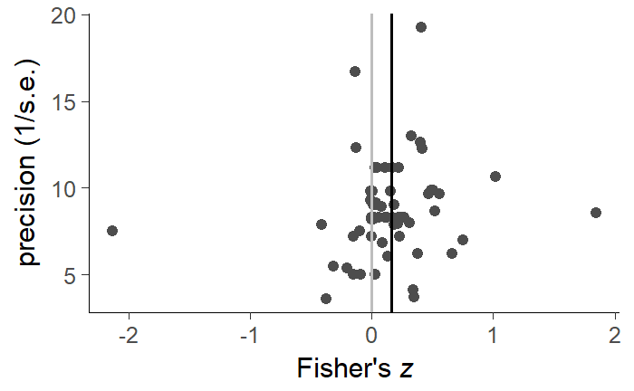

```r
funnel_2
```

# Moderators

## Type of methodological approach

Testing if differences between study methods (obs, exp_lab, exp_field) explain variance in data

```r
meta.mt_mod1 <- rma.mv(yi=yi, V=vi, random = list(~ 1|id.mt, ~1|nID, ~1|species, ~1|phylo), R=list(phylo=cor) , data=dataset3, method="REML", mod= ~ study_type-1)
summary(meta.mt_mod1)
```

```
Multivariate Meta-Analysis Model (k = 69; method: REML)

  logLik  Deviance       AIC       BIC      AICc
-37.6811   75.3621   89.3621  104.6897   91.2932

Variance Components:

            estim    sqrt  nlvls  fixed   factor    R
sigma^2.1  0.1663  0.4078     69     no    id.mt   no
sigma^2.2  0.0000  0.0000     20     no      nID   no
sigma^2.3  0.0000  0.0000     15     no  species   no
sigma^2.4  0.0000  0.0000     15     no    phylo  yes

Test for Residual Heterogeneity:
QE(df = 66) = 834.9421, p-val < .0001

Test of Moderators (coefficient(s) 1:3):
QM(df = 3) = 7.8851, p-val = 0.0484

Model Results:

                     estimate      se    zval    pval    ci.lb   ci.ub
study_typeexp_field    0.0940  0.0680  1.3830  0.1667  -0.0392  0.2273
study_typeexp_lab      0.0885  0.1233  0.7183  0.4726  -0.1531  0.3302
study_typeobs          0.2404  0.1029  2.3359  0.0195   0.0387  0.4422  *

---
Signif. codes:  0 *** 0.001 ** 0.01 * 0.05 . 0.1   1
```

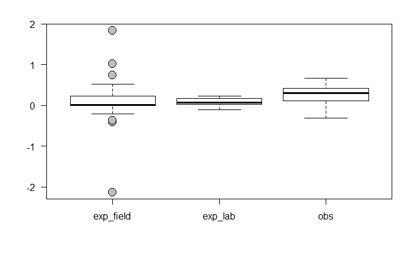

```r
plot(dataset3$study_type, dataset3$yi, las = 1, bty = "l", cex = 2, pch=21, bg=16)
```

```r
table(dataset3$study_type)
```

```
exp_field   exp_lab       obs
       40        12        17
```

## Type of mating system

Testing if differences between monogamy and polygamy mating systems explain variance in data

```r
# social_bond
meta.mt_mod22 <- rma.mv(yi=yi, V=vi, random = list(~ 1|id.mt, ~1|nID, ~1|species, ~1|phylo), R=list(phylo=cor) , data=dataset3, method="REML", mod= ~ mating_system-1)
summary(meta.mt_mod22)
```

```
Multivariate Meta-Analysis Model (k = 69; method: REML)

  logLik  Deviance       AIC       BIC      AICc
-38.3823   76.7647   88.7647  101.9928   90.1647

Variance Components:

            estim    sqrt  nlvls  fixed   factor    R
sigma^2.1  0.1661  0.4075     69     no    id.mt   no
sigma^2.2  0.0000  0.0000     20     no      nID   no
sigma^2.3  0.0010  0.0321     15     no  species   no
sigma^2.4  0.0000  0.0000     15     no    phylo  yes

Test for Residual Heterogeneity:
QE(df = 67) = 844.7329, p-val < .0001

Test of Moderators (coefficient(s) 1:2):
QM(df = 2) = 6.4825, p-val = 0.0391

Model Results:

                       estimate      se    zval    pval    ci.lb   ci.ub
mating_systemmonogamy    0.2399  0.2114  1.1350  0.2564  -0.1744  0.6543
mating_systempolygamy    0.1251  0.0549  2.2791  0.0227   0.0175  0.2326  *

---
Signif. codes:  0 *** 0.001 ** 0.01 * 0.05 . 0.1   1
```

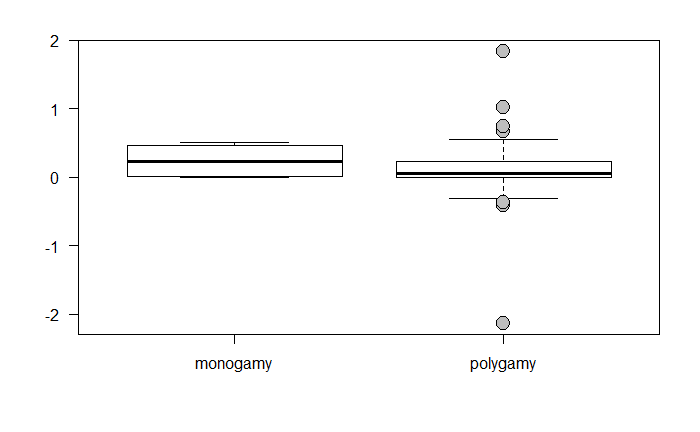

```r
plot(dataset3$mating_system, dataset3$yi, las = 1, bty = "l", cex = 2, pch=21, bg=16)
```

```r
table(dataset3$mating_system)
```

```
monogamy polygamy
       4       65
```

## Type of parental care

Testing if differences between parental care type (maternal, paternal, biparental, no_care) explain variance in data

```r
meta.mt_mod3 <- rma.mv(yi=yi, V=vi, random = list(~ 1|id.mt, ~1|nID, ~1|species, ~1|phylo), R=list(phylo=cor) , data=dataset3, method="REML", mod= ~ care-1)
summary(meta.mt_mod3)
```

```
Multivariate Meta-Analysis Model (k = 69; method: REML)

  logLik  Deviance       AIC       BIC      AICc
-37.4737   74.9475   90.9475  108.3426   93.5189

Variance Components:

            estim    sqrt  nlvls  fixed   factor    R
sigma^2.1  0.1654  0.4067     69     no    id.mt   no
sigma^2.2  0.0000  0.0000     20     no      nID   no
sigma^2.3  0.0000  0.0000     15     no  species   no
sigma^2.4  0.0122  0.1103     15     no    phylo  yes

Test for Residual Heterogeneity:
QE(df = 65) = 809.9814, p-val < .0001

Test of Moderators (coefficient(s) 1:4):
QM(df = 4) = 4.1543, p-val = 0.3855

Model Results:

                estimate      se    zval    pval    ci.lb   ci.ub
carebiparental    0.1512  0.1872  0.8079  0.4191  -0.2156  0.5181
carematernal      0.0131  0.1445  0.0905  0.9279  -0.2702  0.2963
careno_care       0.2665  0.2566  1.0385  0.2990  -0.2365  0.7695
carepaternal      0.1950  0.1112  1.7534  0.0795  -0.0230  0.4129  .

---
Signif. codes:  0 *** 0.001 ** 0.01 * 0.05 . 0.1   1
```

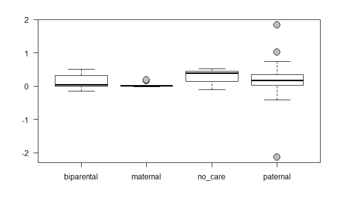

```r
plot(dataset3$care, dataset3$yi, las = 1, bty = "l", cex = 2, pch=21, bg=16)
```

```r
table(dataset3$care)
```

```
biparental   maternal    no_care   paternal
         7         18          3         41
```

# Body part

Testing if arm and body size has different mean values

```r
# arm versus body size
meta.mt_mod4 <- rma.mv(yi=yi, V=vi, random = list(~ 1|id.mt, ~1|nID, ~1|species, ~1|phylo), R=list(phylo=cor) , data=dataset3, method="REML", mod= ~ axb-1)
summary(meta.mt_mod4)
```

```
Multivariate Meta-Analysis Model (k = 69; method: REML)

  logLik  Deviance       AIC       BIC      AICc
-38.2341   76.4683   88.4683  101.6964   89.8683

Variance Components:

            estim    sqrt  nlvls  fixed   factor    R
sigma^2.1  0.1659  0.4074     69     no    id.mt   no
sigma^2.2  0.0000  0.0000     20     no      nID   no
sigma^2.3  0.0000  0.0000     15     no  species   no
sigma^2.4  0.0000  0.0000     15     no    phylo  yes

Test for Residual Heterogeneity:
QE(df = 67) = 835.5746, p-val < .0001

Test of Moderators (coefficient(s) 1:2):
QM(df = 2) = 6.9399, p-val = 0.0311

Model Results:

      estimate      se    zval    pval    ci.lb   ci.ub
axba    0.0293  0.1410  0.2080  0.8352  -0.2470  0.3056
axbb    0.1452  0.0553  2.6262  0.0086   0.0368  0.2536  **

---
Signif. codes:  0 *** 0.001 ** 0.01 * 0.05 . 0.1   1
```

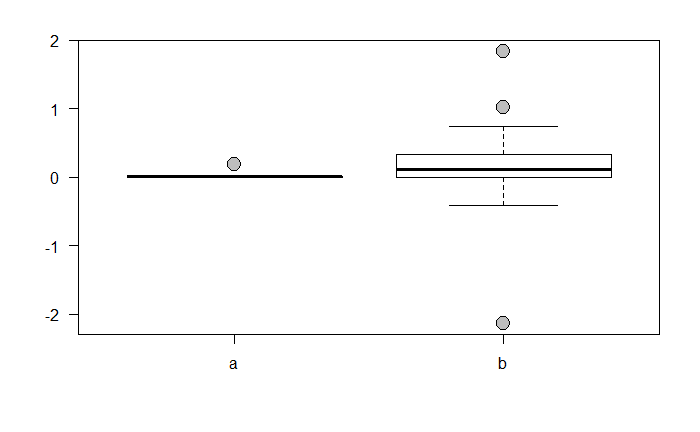

```r
plot(dataset3$axb, dataset3$yi, las = 1, bty = "l", cex = 2, pch=21, bg=16)
```

```r
table(dataset3$axb)
```

```
 a  b
 9 60
```

# Making a better forest plot

First, creating a new data frame, with colunms with the confidence interval

```r
mean.effect <- as.data.frame(matrix(t(mean.effect),nrow=1),stringsAsFactors=FALSE)
class(mean.effect)
```

```
[1] "data.frame"
```

```r
df3.3$yi <- as.character(df3.3$yi)
df3.3$CILB <- as.character(df3.3$CILB)
df3.3$CIUB <- as.character(df3.3$CIUB)
```

```r
df3.3$yi <- as.numeric(df3.3$yi)
df3.3$CILB <- as.numeric(df3.3$CILB)
df3.3$CIUB <- as.numeric(df3.3$CIUB)
```

```r
highlight <- subset(df3.3, ES=="Mean effect size")
```

Now, creating the plot

```r
myplot_3 <- ggplot(df3.3, aes(x=ES)) +
  geom_hline(aes(yintercept=0), linetype="dashed", color="gray", lwd=1) +
  geom_linerange(aes(x=ES, ymin=CILB, ymax=CIUB),col="gray50", lwd=1, alpha=0.7) +
  geom_linerange(aes(x=ES, ymin=CILB, ymax=CIUB), data=highlight, colour="black") +
  geom_point(aes(y=yi, size=yi), shape = 21, fill="grey50", col="grey50") +
  geom_point(aes(y=yi, size=yi), data=highlight, colour="black") +
  scale_size_continuous(range = c(1,5), name="Effect size Zr") +
  scale_x_discrete(limits = rev(levels(df3.3$ES)))+
  ylab(expression(Effect~Size~italic(Zr)))+
  xlab("")+
  theme_bw()+
  coord_flip()+
  guides(fill= guide_legend(override.aes = list(size=5)),
         size = guide_legend(override.aes = list(fill = "gray40")))+
  theme(panel.border = element_blank(),
        panel.grid.major = element_blank(),
        panel.grid.minor = element_blank(),
        axis.text.x = element_text(size=12),
        axis.text.y = element_text(size=10),
        axis.line = element_line(colour = "black"),
        legend.position = "none")
```

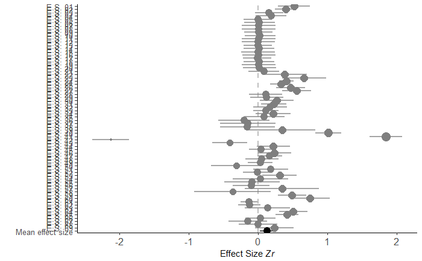

```r
myplot_3
```